# Analyse

# Grenouille des bois

## Variable réponse (Présence ou absence de la grenouille des bois)

Les données sont celles de 2022 seulement puisqu’il n’y a aucune observation en 2021 (les enregistrements ont commencé trop tard). Les observations de l’espèces ont eu lieu à 21h et à 1h.

Nombre d’observations: 25

Nombre de sites où l’espèce est observée : 11

```r
str(lisyl)
```

```
## 'data.frame':    26 obs. of  4 variables:
##  $ V1: int  0 0 1 0 0 0 0 NA 0 0 ...
##  $ V2: int  0 0 0 0 0 0 0 NA 0 0 ...
##  $ V3: int  0 0 1 0 0 0 0 0 1 0 ...
##  $ V4: int  0 0 1 0 0 0 0 0 1 0 ...
```

## Variables de détection

- **Types de Perturbation** : Human, meteo ou none
- **Qualité de l’enregistrement** : Good, moderate ou bad
- **Heure de l’enregistrement**: 21h ou 1h
- **Date de l’enregistrement**: en jour julien

Difficile de joindre ensemble deux classes de données pour qualité de l’enregistrement. J’ai de loin beaucoup plus de moderate que de bad ou good

```r
table(anoure$RecordingQuality)
```

```
##
##      bad     good moderate
##      231      449     1125
```

### Corrélation des variables

```r
table(anoure$RecordingQuality, anoure$DisturbanceType)
```

```
##
##            human meteo none
##   bad          6   225    0
##   good       128    47  274
##   moderate   557   568    0
```

```r
str(jj_lisyl)
```

```
## 'data.frame':    26 obs. of  4 variables:
##  $ V1: int  108 108 109 109 109 109 111 NA 109 109 ...
##  $ V2: int  109 109 110 110 110 110 112 NA 110 110 ...
##  $ V3: int  115 115 115 115 115 115 115 116 115 115 ...
##  $ V4: int  116 116 116 116 116 116 116 117 116 116 ...
```

```r
str(heure_lisyl)
```

```
## 'data.frame':    26 obs. of  4 variables:
##  $ V1: int  21 21 21 21 21 21 21 NA 21 21 ...
##  $ V2: int  1 1 1 1 1 1 1 NA 1 1 ...
##  $ V3: int  21 21 21 21 21 21 21 21 21 21 ...
##  $ V4: int  1 1 1 1 1 1 1 1 1 1 ...
```

C’est certain que heure et date sont très corrélés. Est-ce que c’est juste de garder les deux dans les modèles? Selon moi c’est pour ça qu’on voit ce warning quand je roule les poids AIC des modèles : *Warning: Check model structure carefully as some models may be redundant*

## Variables d’occupation

- **Milieux humide** : Regroupement de Milieu humide, Tourbières et Marécage (à partir de la couche de milieu humide)
- **Eau libre** : Regroupement de Marais, Lac, Eau peu profonde et Eau (à partir de la couche de milieu humide et la couche d’utilisation du territoire)
- **Route** : Nombre de km de route total
- **Agriculture** : Regroupement de tous les types d’agriculture
- **Site** : Si le site est en lisière ou en forêt (donnée prise lors de la pause des enregistreurs)

```r
str(occupation)
```

```
## 'data.frame':    26 obs. of  6 variables:
##  $ Enregistre : chr  "C-foret" "C-lisiere" "E-foret" "E-lisiere" ...
##  $ Route      : num  0 543 0 524 0 ...
##  $ Agriculture: num  16090.91 62919.49 829.63 5286.92 5.14 ...
##  $ Eau        : num  0 0 0 0 59648 ...
##  $ Humide     : num  262143 221146 282415 251632 247288 ...
##  $ Site       : chr  "foret" "lisiere" "foret" "lisiere" ...
```

### Corrélation des variables

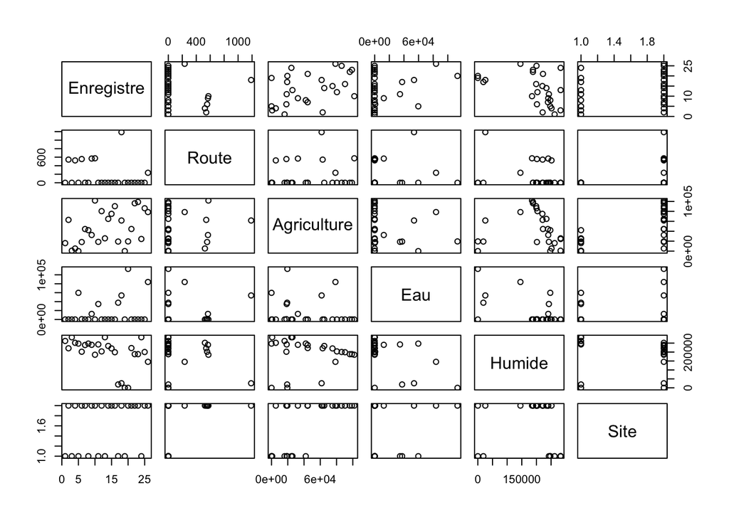

```r
plot(occupation)
```

## Création des modèles

Création du tableau de données pour le package unmarked

```r
lisyl.data <- unmarkedFrameOccu(y = lisyl, siteCovs = occupation, obsCovs = list(disturbance = perturb_lisyl, qualite = qualite_lisyl, heure = heure_lisyl, date = jj_lisyl))
summary(lisyl.data)
```

```
## unmarkedFrame Object
##
## 26 sites
## Maximum number of observations per site: 4
## Mean number of observations per site: 3.92
## Sites with at least one detection: 11
##
## Tabulation of y observations:
##    0    1 <NA>
##   77   25    2
##
## Site-level covariates:
##      Enregistre     Route         Agriculture             Eau
##  C-foret  : 1   Min.   :   0.0   Min.   :     5.14   Min.   :     0
##  C-lisiere: 1   1st Qu.:   0.0   1st Qu.: 18795.08   1st Qu.:     0
##  E-foret  : 1   Median :   0.0   Median : 43289.47   Median :     0
##  E-lisiere: 1   Mean   : 161.1   Mean   : 46506.54   Mean   : 15236
##  F-foret  : 1   3rd Qu.: 175.6   3rd Qu.: 77739.69   3rd Qu.:  9517
##  F-lisiere: 1   Max.   :1187.3   Max.   :101863.09   Max.   :113276
##  (Other)  :20
##      Humide            Site
##  Min.   :     0   foret  : 9
##  1st Qu.:188215   lisiere:17
##  Median :220775
##  Mean   :193579
##  3rd Qu.:246110
##  Max.   :282781
##
##
## Observation-level covariates:
##  disturbance     qualite       heure         date
##  human:29    bad     : 4   Min.   : 1   Min.   :108.0
##  meteo:21    good    :66   1st Qu.: 1   1st Qu.:111.0
##  none :52    moderate:32   Median :11   Median :115.0
##  NA's : 2    NA's    : 2   Mean   :11   Mean   :113.1
##                            3rd Qu.:21   3rd Qu.:116.0
##                            Max.   :21   Max.   :117.0
##                            NA's   :2    NA's   :2
```

Modèles

```r
#Détectabilité et occupation constante
m0 <- occu(~ 1 ~ 1, data = lisyl.data)

##Détectabilité varie selon la qualité de l'enregistrement et l'occupation varie selon...
mQH <- occu(~ qualite ~ Humide, data = lisyl.data)
mQE <- occu(~ qualite ~ Eau, data = lisyl.data)
mQR <- occu(~ qualite ~ Route, data = lisyl.data)
mQA <- occu(~ qualite ~ Agriculture, data = lisyl.data)
mQS <- occu(~ qualite ~ Site, data = lisyl.data)

##Détectabilité varie selon le type de perturbation et occupation varie selon ...
mPH <- occu(~ disturbance ~ Humide, data = lisyl.data)
mPE <- occu(~ disturbance ~ Eau, data = lisyl.data)
mPR <- occu(~ disturbance ~ Route, data = lisyl.data)
mPA <- occu(~ disturbance ~ Agriculture, data = lisyl.data)
mPS <- occu(~ disturbance ~ Site, data = lisyl.data)

##Détectabilité varie selon l'heure et occupation varie selon ...
mHH <- occu(~ heure ~ Humide, data = lisyl.data)
mHE <- occu(~ heure ~ Eau, data = lisyl.data)
mHR <- occu(~ heure ~ Route, data = lisyl.data)
mHA <- occu(~ heure ~ Agriculture, data = lisyl.data)
mHS <- occu(~ heure ~ Site, data = lisyl.data)

##Détectabilité varie selon les jours juliens et occupation varie selon ...
mDH <- occu(~ date ~ Humide, data = lisyl.data)
mDE <- occu(~ date ~ Eau, data = lisyl.data)
mDR <- occu(~ date ~ Route, data = lisyl.data)
mDA <- occu(~ date ~ Agriculture, data = lisyl.data)
mDS <- occu(~ date ~ Site, data = lisyl.data)
```

Tableau de tous les modèles avec le poid AIC

```r
Cands <- list(m0, mQH, mQE, mQR, mQA, mQS, mPH, mPE, mPR, mPA, mPS, mHH, mHE, mHR, mHA, mHS, mDH, mDE, mDR, mDA, mDS)

##Donner les noms significaifs aux modèles
Model.names <- c("nul","psi(Milieux humides)p(Qualité)", "psi(Eau libre)p(Qualité)", "psi(Route)p(Qualité)", "psi(Agriculture)p(Qualité)", "psi(Site)p(Qualité)", "psi(Milieux humides)p(Perturb)", "psi(Eau libre)p(Perturb)", "psi(Route)p(Perturb)", "psi(Agriculture)p(Perturb)", "psi(Site)p(Perturb)", "psi(Milieux humides)p(Heure)", "psi(Eau libre)p(Heure)", "psi(Route)p(Heure)", "psi(Agriculture)p(Heure)", "psi(Site)p(Heure)", "psi(Milieux humides)p(Date)", "psi(Eau libre)p(Date)", "psi(Route)p(Date)", "psi(Agriculture)p(Date)", "psi(Site)p(Date)")

##do model selection based on AICc
aictab(cand.set = Cands,  modnames = Model.names)
```

```
##
## Model selection based on AICc:
##
##                                K   AICc Delta_AICc AICcWt Cum.Wt     LL
## psi(Route)p(Date)              4  96.86       0.00   0.38   0.38 -43.48
## psi(Route)p(Heure)             4  99.01       2.15   0.13   0.51 -44.55
## nul                            2  99.01       2.16   0.13   0.64 -47.25
## psi(Route)p(Qualité)           5  99.10       2.25   0.12   0.76 -43.05
## psi(Site)p(Date)               4  99.87       3.01   0.08   0.85 -44.98
## psi(Route)p(Perturb)           5 101.65       4.80   0.03   0.88 -44.33
## psi(Site)p(Qualité)            5 101.74       4.88   0.03   0.91 -44.37
## psi(Site)p(Heure)              4 102.14       5.29   0.03   0.94 -46.12
## psi(Site)p(Perturb)            5 104.57       7.71   0.01   0.95 -45.78
## psi(Agriculture)p(Date)        4 104.80       7.94   0.01   0.96 -47.45
## psi(Agriculture)p(Heure)       4 104.80       7.94   0.01   0.96 -47.45
## psi(Milieux humides)p(Heure)   4 104.80       7.95   0.01   0.97 -47.45
## psi(Milieux humides)p(Date)    4 104.80       7.95   0.01   0.98 -47.45
## psi(Eau libre)p(Heure)         4 104.80       7.95   0.01   0.98 -47.45
## psi(Eau libre)p(Date)          4 104.80       7.95   0.01   0.99 -47.45
## psi(Agriculture)p(Perturb)     5 107.89      11.04   0.00   0.99 -47.45
## psi(Agriculture)p(Qualité)     5 107.89      11.04   0.00   0.99 -47.45
## psi(Milieux humides)p(Qualité) 5 107.90      11.04   0.00   1.00 -47.45
## psi(Milieux humides)p(Perturb) 5 107.90      11.04   0.00   1.00 -47.45
## psi(Eau libre)p(Qualité)       5 107.90      11.04   0.00   1.00 -47.45
## psi(Eau libre)p(Perturb)       5 107.90      11.04   0.00   1.00 -47.45
```

### Vérification ajustement du modèle

Modèle avec le plus de poid est celui avec **Route** et **Date**

```r
mDR
```

```
##
## Call:
## occu(formula = ~date ~ Route, data = lisyl.data)
##
## Occupancy:
##             Estimate     SE      z P(>|z|)
## (Intercept)  0.16825 0.4817  0.349   0.727
## Route       -0.00316 0.0021 -1.503   0.133
##
## Detection:
##             Estimate     SE     z P(>|z|)
## (Intercept)  -28.523 15.019 -1.90  0.0576
## date           0.253  0.133  1.91  0.0564
##
## AIC: 94.95086
```

Code ajustement du modèle

```r
ajust <- mb.gof.test(mDR, nsim = 5000, plot.hist=T)
save(ajust, file = "lisyl_ajust_gof.Rdata")
```

Le mb.gof.test produit vraiment beaucoup de ces warning: producedWarning: NAs. Est-ce que c’est grave?

```r
load("lisyl_ajust_gof.Rdata")
ajust
```

```
##
## MacKenzie and Bailey goodness-of-fit for single-season occupancy model
##
## Pearson chi-square table:
##
##      Cohort Observed Expected Chi-square
## 0000      0       14    14.42       0.01
## 0010      0        2     0.79       1.87
## 0011      0        2     1.89       0.01
## 0111      0        1     1.32       0.08
## 1000      0        1     0.23       2.60
## 1001      0        1     0.55       0.37
## 1011      0        2     1.02       0.93
## 1110      0        1     0.34       1.27
## 1111      0        1     0.82       0.04
## ..00      1        1     0.50       0.51
##
## Chi-square statistic = 11.7998
## Number of bootstrap samples = 5000
## P-value = 0.7106
##
## Quantiles of bootstrapped statistics:
##   0%  25%  50%  75% 100%
##  2.3 11.3 14.5 18.4 69.7
##
## Estimate of c-hat = 0.77
```

##### Refaire la sélection de modèles avec ajustement

Le warning de R dit que je dois garder 1 si le c.hat est inférieur à 1:

*Error in AICc.unmarkedFit(X[[i]], …) : You should set ‘c.hat’ to 1 if < 1, but values << 1 might also indicate lack of fit*

Ce qui revient aux même aictab qu’avant